# A general framework to run analyses in Dias et al.xxxxx

Gabriel Santos

Guilherme Sanches

last time knit: 2025-05-05 (17:54:24)

# Setting & SessionInfo

Define packages used in this paper

```r
library(openxlsx)
library(car)
library(performance)
library(tidyverse)
library(MuMIn)
library(performance)
library(lme4)
library(see)
library(DHARMa)
library(sjPlot)
library(ggplot2)
library(ggeffects)

options(na.action=na.fail)  #Define na action to run dredge function from MuMIn
```

# Load data

## Data development

Overview data for individual development

> Metadata: - Etiqueta: a ID code of the individual - Imersion to Adulto: data stage was first recorded - Note data in Imersion to Adult represent dates and must be converted properly! - SP: species - Sexo: Sex - Temp: Temperature individual developed - Locality - ID: Is a full ID include etiqueta, temperature, species and locality - Days to change ontogenetic stage - L2_L1 means, Become stage L2 from stage L1 - L3_L2 means, Become stage L3 from stage L2 - Adulto_Imersion represent the total number of days from first immersion to adult stage - So on…

```r
dados<-read.xlsx("Book1.xlsx",sheet="Goias_CLEAN_2")
  dados<-dados%>%select(-L1_IMERSION)

dados
```

|  | Etiqueta | IMERSION | L1 | L2 | L3 | L4 | PUPA | ADULTO | SP | SEXO | temp | Localidade | ID_etiqueta_temp_local | L2_L1 | L3_L2 | L4_L3 | PUPA_L4 | ADULTO_PUPA | ADULTO_IMERSION |
| --- | --- | --- | --- | --- | --- | --- | --- | --- | --- | --- | --- | --- | --- | --- | --- | --- | --- | --- | --- |
| 1 | 3 | 45462 | 45462 | 45465 | 45467 | 45471 | 45472 | 45474 | Aedes terrens | M | 30 | Goias | 3_30C_Aedes terrens_Goias | 3 | 2 | 4 | 1 | 2 | 12 |
| 2 | 3 | 45217 | 45217 | 45222 | 45224 | 45227 | 45234 | 45239 | Aedes terrens | F | 20 | Goias | 3_20C_Aedes terrens_Goias | 5 | 2 | 3 | 7 | 5 | 22 |
| 3 | 4 | 45217 | 45217 | 45222 | 45224 | 45227 | 45233 | 45238 | Aedes terrens | M | 20 | Goias | 4_20C_Aedes terrens_Goias | 5 | 2 | 3 | 6 | 5 | 21 |
| 4 | 5 | 45217 | 45217 | 45222 | 45224 | 45227 | 45235 | 45238 | Aedes terrens | F | 20 | Goias | 5_20C_Aedes terrens_Goias | 5 | 2 | 3 | 8 | 3 | 21 |
| 5 | 6 | 45217 | 45217 | 45222 | 45225 | 45228 | 45236 | 45241 | Aedes terrens | M | 20 | Goias | 6_20C_Aedes terrens_Goias | 5 | 3 | 3 | 8 | 5 | 24 |
| 6 | 9 | 45226 | 45226 | 45229 | 45232 | 45235 | 45243 | 45247 | Aedes terrens | M | 20 | Goias | 9_20C_Aedes terrens_Goias | 3 | 3 | 3 | 8 | 4 | 21 |
| 7 | 10 | 45230 | 45230 | 45233 | 45235 | 45238 | 45245 | 45250 | Aedes terrens | F | 20 | Goias | 10_20C_Aedes terrens_Goias | 3 | 2 | 3 | 7 | 5 | 20 |
| 8 | 11 | 45462 | 45462 | 45464 | 45466 | 45467 | 45471 | 45472 | Aedes terrens | F | 30 | Goias | 11_30C_Aedes terrens_Goias | 2 | 2 | 1 | 4 | 1 | 10 |
| 9 | 12 | 45462 | 45462 | 45464 | 45467 | 45470 | 45472 | 45474 | Aedes terrens | M | 30 | Goias | 12_30C_Aedes terrens_Goias | 2 | 3 | 3 | 2 | 2 | 12 |
| 10 | 13 | 45462 | 45462 | 45465 | 45466 | 45468 | 45472 | 45475 | Aedes terrens | M | 25 | Goias | 13_25C_Aedes terrens_Goias | 3 | 1 | 2 | 4 | 3 | 13 |

[output cut: 186 more lines]

## Data eclosion

```r
dados_eclosion<-read.xlsx("Experimento 1 (Temperatura).xlsx",sheet="Ovitrampa Goiás ") #Tem um "espaço a mais na aba ovitrampa Goiais, cuidado!

dados_eclosion
```

|  | Ovitrampa | Total.de.ovos | Ovos.eclodidos | Temperatura | Local |
| --- | --- | --- | --- | --- | --- |
| 1 | 6 (3 paletas) | 226 | 130 | 25°C | Goiás |
| 2 | 7 (3 paletas) | 115 | 83 | 30°C | Goiás |
| 3 | 2 (3 paletas) | 121 | 14 | 30°C | Goiás |
| 4 | 9 (3 paletas) | 106 | 7 | 20°C | Goiás |
| 5 | 8 (3 paletas) | 23 | 2 | 20°C | Goiás |
| 6 | 1 (3 paletas) | 27 | 1 | 20°C | Goiás |
| 7 | 3 (3 paletas) | 25 | 0 | 20°C | Goiás |
| 8 | 14 (3 paletas) | 18 | 0 | 15°C | Goiás |
| 9 | 5 (3 paletas) | 35 | 0 | 15°C | Goiás |
| 10 | 12 (3 paletas) | 50 | 0 | 15°C | Goiás |

[output cut: 1 more lines]

# Eclosion model

## Data preparation

```r
dados_eclosion$Temperatura<-c(25,30,30,20,20,20,20,15,15,15,15) #Necessário para tirar o "ºC"

dados_eclosion$Temperatura<-as.numeric(dados_eclosion$Temperatura)

dados_eclosion%>%
group_by(Temperatura)%>%
summarise(Eclosion_rate=mean((Ovos.eclodidos/Total.de.ovos)*100),
sd=sd((Ovos.eclodidos/Total.de.ovos)*100),
N=n())
```

| Temperatura | Eclosion_rate | sd | N |
| --- | --- | --- | --- |
| 15 | 0.00 | 0.00 | 4 |
| 20 | 4.75 | 3.77 | 4 |
| 25 | 57.52 | NA | 1 |
| 30 | 41.87 | 42.85 | 2 |

## Model implementation

### Full model and model selection

```r
eclosion_mod<-glm(cbind(Ovos.eclodidos,Total.de.ovos)~
              Temperatura+I(Temperatura^2),family = binomial("logit"),data=dados_eclosion)

dredge(eclosion_mod)
```

```
Fixed term is "(Intercept)"
```

```
Global model call: glm(formula = cbind(Ovos.eclodidos, Total.de.ovos) ~ Temperatura +
    I(Temperatura^2), family = binomial("logit"), data = dados_eclosion)
---
Model selection table
  (Intrc) Tmprt  Tmprt^2 df logLik  AICc
4  -39.48 2.911 -0.05417  3  -35.3  80.1
2   -5.43 0.166           2  -77.1 159.7
3   -3.33        0.00317  2  -84.6 174.7
1   -1.28                 1 -133.2 268.9
  delta weight
4   0.0      1
2  79.6      0
3  94.6      0
1 188.8      0
Models ranked by AICc(x)
```

### Best Model validation

Best models is the full model so no additional script is necessary

```
$uniformity

    Exact one-sample Kolmogorov-Smirnov test

data:  simulationOutput$scaledResiduals
D = 0.2, p-value = 0.8
alternative hypothesis: two-sided


$dispersion

    DHARMa nonparametric dispersion test via
    sd of residuals fitted vs. simulated

data:  simulationOutput
dispersion = 1, p-value = 0.4
alternative hypothesis: two.sided


$outliers

    DHARMa bootstrapped outlier test

data:  simulationOutput
outliers at both margin(s) = 2,
observations = 11, p-value <2e-16
alternative hypothesis: two.sided
 percent confidence interval:
 0 0
sample estimates:
outlier frequency (expected: 0.00181818181818182 )
                                             0.182
```

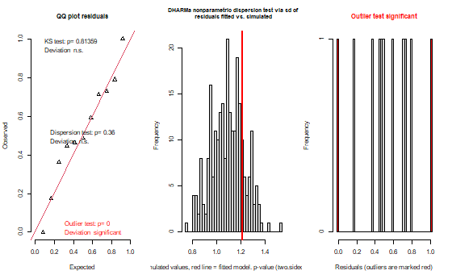

```r
simulateResiduals(eclosion_mod, plot =F)%>%testResiduals()
```

## Model validation

[output not shown]

[figure not shown]

```r
simulateResiduals(eclosion_mod, plot =F)%>%testResiduals()
```

## Model inference

Now, use the best model to drawn conclusions

### Summary

```r
summary(eclosion_mod)
```

```
Call:
glm(formula = cbind(Ovos.eclodidos, Total.de.ovos) ~ Temperatura +
    I(Temperatura^2), family = binomial("logit"), data = dados_eclosion)

Coefficients:
                  Estimate Std. Error z value
(Intercept)      -39.47693    5.51094   -7.16
Temperatura        2.91124    0.42138    6.91
I(Temperatura^2)  -0.05417    0.00799   -6.78
                 Pr(>|z|)
(Intercept)       7.9e-13 ***
Temperatura       4.9e-12 ***
I(Temperatura^2)  1.2e-11 ***
---
Signif. codes:
0 ‘***’ 0.001 ‘**’ 0.01 ‘*’ 0.05 ‘.’ 0.1 ‘ ’ 1

(Dispersion parameter for binomial family taken to be 1)

    Null deviance: 241.871  on 10  degrees of freedom
Residual deviance:  46.105  on  8  degrees of freedom
AIC: 76.69

Number of Fisher Scoring iterations: 5
```

### Optimum temperature

Values predicted by best model was extract for temperature from 20ºC to 30ºC by 0.5ºC intervals x is x-axis value, it means, temperature in this case

Optimum temperature is

```r
eclosion_mod_pred<-ggpredict(eclosion_mod, terms = c("Temperatura[20:30,by=.5]"))

eclosion_mod_pred%>%as.tibble()%>%
    slice_max(predicted,n = 5)%>%arrange(x)%>%select(-group) #x is temperature
```

| x | predicted | std.error | conf.low | conf.high |
| --- | --- | --- | --- | --- |
| 26.0 | 0.401 | 0.1087 | 0.351 | 0.453 |
| 26.5 | 0.409 | 0.1072 | 0.359 | 0.461 |
| 27.0 | 0.411 | 0.1047 | 0.362 | 0.461 |
| 27.5 | 0.406 | 0.1014 | 0.359 | 0.454 |
| 28.0 | 0.394 | 0.0983 | 0.349 | 0.441 |

### Plot

```
Raw data not available.
```

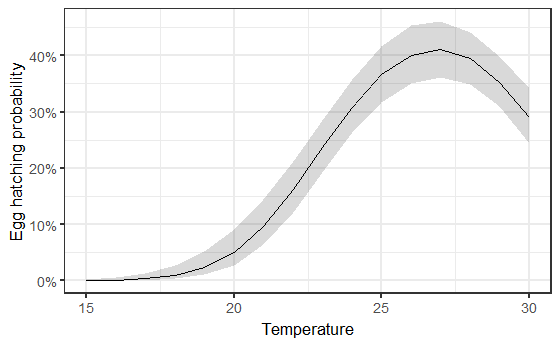

```r
plot_model(eclosion_mod, type = "pred", terms = "Temperatura[15:30]",show.data = T,colors = "bw")+
xlab("Temperature")+ylab("Egg hatching probability")+
labs(title=NULL)+
theme_bw(base_size=16)
```

# Eggs survival

## Data preparation

```r
surv <- data.frame(
  Vivos = c(7, 109, 80),
  Mortos = c(3, 19, 14),
  Temperatura = c(20, 25, 30))%>%
mutate(Total=Vivos+Mortos)

surv
```

| Vivos | Mortos | Temperatura | Total |
| --- | --- | --- | --- |
| 7 | 3 | 20 | 10 |
| 109 | 19 | 25 | 128 |
| 80 | 14 | 30 | 94 |

## Model implementation and validation

A simple glm with binomial distribution was used

DHARMa package was used because there is very few observation and the `DHARMa::imulateResiduals` function improves performance in this case

```r
mod_surv<-glm(cbind(Mortos,Total)~
        Temperatura+I(Temperatura^2),family = binomial("logit"),data=surv)

dredge(mod_surv)
```

```
Fixed term is "(Intercept)"
```

```
Global model call: glm(formula = cbind(Mortos, Total) ~ Temperatura + I(Temperatura^2),
    family = binomial("logit"), data = surv)
---
Model selection table
  (Intrc)   Tmprt  Tmprt^2 df logLik AICc
4   8.680 -0.7770  0.01414  3  -5.87 -6.3
1  -1.863                   1  -6.34 18.7
2  -0.943 -0.0345           2  -6.18  Inf
3  -1.438         -0.00059  2  -6.21  Inf
  delta weight
4   0.0      1
1  24.9      0
2   Inf      0
3   Inf      0
Models ranked by AICc(x)
```

```
$uniformity

    Exact one-sample Kolmogorov-Smirnov test

data:  simulationOutput$scaledResiduals
D = 0.5, p-value = 0.3
alternative hypothesis: two-sided


$dispersion

    DHARMa nonparametric dispersion test via
    sd of residuals fitted vs. simulated

data:  simulationOutput
dispersion = 0.9, p-value = 0.9
alternative hypothesis: two.sided


$outliers

    DHARMa bootstrapped outlier test

data:  simulationOutput
outliers at both margin(s) = 0,
observations = 3, p-value = 1
alternative hypothesis: two.sided
 percent confidence interval:
 0 0
sample estimates:
outlier frequency (expected: 0.00333333333333333 )
                                                 0
```

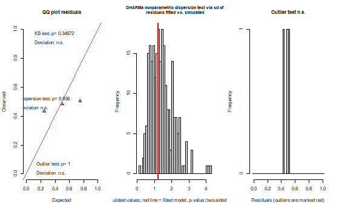

```r
# Modelo validation
simulateResiduals(mod_surv, plot =F)%>%testResiduals()
```

## Model inference

```r
mod_surv%>%parameters::parameters()
```

```
Parameter     | Log-Odds |    SE |          95% CI |     z |     p
------------------------------------------------------------------
(Intercept)   |     8.68 | 11.85 | [-16.67, 30.99] |  0.73 | 0.464
Temperatura   |    -0.78 |  0.91 | [ -2.51,  1.15] | -0.85 | 0.394
Temperatura^2 |     0.01 |  0.02 | [ -0.02,  0.05] |  0.81 | 0.417
```

```
Uncertainty intervals
  (profile-likelihood) and p-values
  (two-tailed) computed using a Wald
  z-distribution approximation.

The model has a log- or logit-link.
  Consider using `exponentiate = TRUE` to
  interpret coefficients as ratios.
```

```
Raw data not available.
```

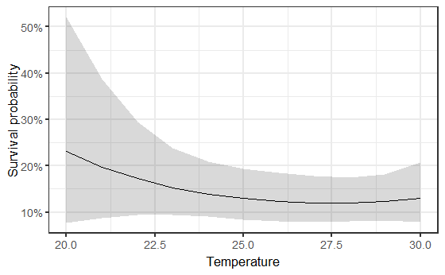

```r
plot_model(mod_surv, type = "pred", terms = "Temperatura[20:30]",show.data = T,colors = "bw")+
xlab("Temperature")+ylab("Survival probability")+
labs(title=NULL)+
theme_bw(base_size=16)
```

# Development

## Data preparation

```r
dados_long<-dados%>%
    select(SEXO,temp,L2_L1:ADULTO_IMERSION)%>%
        pivot_longer(!c(SEXO,temp),
            names_to="Transition",values_to="Days")%>%
filter(Transition!="ADULTO_IMERSION")   # Need to be removed to avoid being double accounted

dados_long
```

| SEXO | temp | Transition | Days |
| --- | --- | --- | --- |
| M | 30 | L2_L1 | 3 |
| M | 30 | L3_L2 | 2 |
| M | 30 | L4_L3 | 4 |
| M | 30 | PUPA_L4 | 1 |
| M | 30 | ADULTO_PUPA | 2 |
| F | 20 | L2_L1 | 5 |
| F | 20 | L3_L2 | 2 |
| F | 20 | L4_L3 | 3 |
| F | 20 | PUPA_L4 | 7 |
| F | 20 | ADULTO_PUPA | 5 |

[output cut: 970 more lines]

### Data summary and standardization

```r
dados%>%
    select(SEXO,temp,L2_L1:ADULTO_IMERSION)%>%
        pivot_longer(!c(SEXO,temp),
            names_to="Transition",values_to="Days")%>%
#   group_by(SEXO,Transition,temp)%>%   #Use this for a complete summary
    group_by(temp)%>%filter(Transition=="ADULTO_IMERSION")%>%
        summarise(Mean_Days=round(mean(Days),2),
            SD_Days=round(sd(Days),2),
            Min=min(Days),
            Max=max(Days),
            low95=quantile(Days,0.025),
            high95=quantile(Days,0.975))%>%
                            data.frame()
```

| temp | Mean_Days | SD_Days | Min | Max | low95 | high95 |
| --- | --- | --- | --- | --- | --- | --- |
| 20 | 22.0 | 1.83 | 20 | 25 | 20.15 | 24.9 |
| 25 | 14.6 | 1.59 | 12 | 22 | 13.00 | 19.0 |
| 30 | 11.7 | 1.41 | 8 | 15 | 9.95 | 15.0 |

```r
NA
```

### Data transformation

Necessary step to reduce dispersion and make ontogenic stages comparable

```r
# Log transformation to reduce dispersion
dados_log<-dados %>%
  mutate(SEXO=as.factor(SEXO))%>%
  mutate(across(L2_L1:ADULTO_IMERSION,log))

#z-score transformation to make models among different stages comparable
dados_std<-dados %>%
  mutate(SEXO=as.factor(SEXO))%>%
  mutate(across(L2_L1:ADULTO_IMERSION,scale))


dados_std
```

|  | Etiqueta | IMERSION | L1 | L2 | L3 | L4 | PUPA | ADULTO | SP | SEXO | temp | Localidade | ID_etiqueta_temp_local | L2_L1 | L3_L2 | L4_L3 | PUPA_L4 | ADULTO_PUPA | ADULTO_IMERSION |
| --- | --- | --- | --- | --- | --- | --- | --- | --- | --- | --- | --- | --- | --- | --- | --- | --- | --- | --- | --- |
| 1 | 3 | 45462 | 45462 | 45465 | 45467 | 45471 | 45472 | 45474 | Aedes terrens | M | 30 | Goias | 3_30C_Aedes terrens_Goias | -0.150 | 0.0193 | 1.766 | -1.914 | -0.672 | -0.645 |
| 2 | 3 | 45217 | 45217 | 45222 | 45224 | 45227 | 45234 | 45239 | Aedes terrens | F | 20 | Goias | 3_20C_Aedes terrens_Goias | 1.575 | 0.0193 | 0.780 | 2.301 | 2.733 | 3.184 |
| 3 | 4 | 45217 | 45217 | 45222 | 45224 | 45227 | 45233 | 45238 | Aedes terrens | M | 20 | Goias | 4_20C_Aedes terrens_Goias | 1.575 | 0.0193 | 0.780 | 1.599 | 2.733 | 2.801 |
| 4 | 5 | 45217 | 45217 | 45222 | 45224 | 45227 | 45235 | 45238 | Aedes terrens | F | 20 | Goias | 5_20C_Aedes terrens_Goias | 1.575 | 0.0193 | 0.780 | 3.004 | 0.463 | 2.801 |
| 5 | 6 | 45217 | 45217 | 45222 | 45225 | 45228 | 45236 | 45241 | Aedes terrens | M | 20 | Goias | 6_20C_Aedes terrens_Goias | 1.575 | 1.2786 | 0.780 | 3.004 | 2.733 | 3.950 |
| 6 | 9 | 45226 | 45226 | 45229 | 45232 | 45235 | 45243 | 45247 | Aedes terrens | M | 20 | Goias | 9_20C_Aedes terrens_Goias | -0.150 | 1.2786 | 0.780 | 3.004 | 1.598 | 2.801 |
| 7 | 10 | 45230 | 45230 | 45233 | 45235 | 45238 | 45245 | 45250 | Aedes terrens | F | 20 | Goias | 10_20C_Aedes terrens_Goias | -0.150 | 0.0193 | 0.780 | 2.301 | 2.733 | 2.418 |
| 8 | 11 | 45462 | 45462 | 45464 | 45466 | 45467 | 45471 | 45472 | Aedes terrens | F | 30 | Goias | 11_30C_Aedes terrens_Goias | -1.012 | 0.0193 | -1.193 | 0.194 | -1.807 | -1.410 |
| 9 | 12 | 45462 | 45462 | 45464 | 45467 | 45470 | 45472 | 45474 | Aedes terrens | M | 30 | Goias | 12_30C_Aedes terrens_Goias | -1.012 | 1.2786 | 0.780 | -1.211 | -0.672 | -0.645 |
| 10 | 13 | 45462 | 45462 | 45465 | 45466 | 45468 | 45472 | 45475 | Aedes terrens | M | 25 | Goias | 13_25C_Aedes terrens_Goias | -0.150 | -1.2401 | -0.206 | 0.194 | 0.463 | -0.262 |

[output cut: 186 more lines]

```r
dados_log
```

|  | Etiqueta | IMERSION | L1 | L2 | L3 | L4 | PUPA | ADULTO | SP | SEXO | temp | Localidade | ID_etiqueta_temp_local | L2_L1 | L3_L2 | L4_L3 | PUPA_L4 | ADULTO_PUPA | ADULTO_IMERSION |
| --- | --- | --- | --- | --- | --- | --- | --- | --- | --- | --- | --- | --- | --- | --- | --- | --- | --- | --- | --- |
| 1 | 3 | 45462 | 45462 | 45465 | 45467 | 45471 | 45472 | 45474 | Aedes terrens | M | 30 | Goias | 3_30C_Aedes terrens_Goias | 1.099 | 0.693 | 1.386 | 0.000 | 0.693 | 2.48 |
| 2 | 3 | 45217 | 45217 | 45222 | 45224 | 45227 | 45234 | 45239 | Aedes terrens | F | 20 | Goias | 3_20C_Aedes terrens_Goias | 1.609 | 0.693 | 1.099 | 1.946 | 1.609 | 3.09 |
| 3 | 4 | 45217 | 45217 | 45222 | 45224 | 45227 | 45233 | 45238 | Aedes terrens | M | 20 | Goias | 4_20C_Aedes terrens_Goias | 1.609 | 0.693 | 1.099 | 1.792 | 1.609 | 3.04 |
| 4 | 5 | 45217 | 45217 | 45222 | 45224 | 45227 | 45235 | 45238 | Aedes terrens | F | 20 | Goias | 5_20C_Aedes terrens_Goias | 1.609 | 0.693 | 1.099 | 2.079 | 1.099 | 3.04 |
| 5 | 6 | 45217 | 45217 | 45222 | 45225 | 45228 | 45236 | 45241 | Aedes terrens | M | 20 | Goias | 6_20C_Aedes terrens_Goias | 1.609 | 1.099 | 1.099 | 2.079 | 1.609 | 3.18 |
| 6 | 9 | 45226 | 45226 | 45229 | 45232 | 45235 | 45243 | 45247 | Aedes terrens | M | 20 | Goias | 9_20C_Aedes terrens_Goias | 1.099 | 1.099 | 1.099 | 2.079 | 1.386 | 3.04 |
| 7 | 10 | 45230 | 45230 | 45233 | 45235 | 45238 | 45245 | 45250 | Aedes terrens | F | 20 | Goias | 10_20C_Aedes terrens_Goias | 1.099 | 0.693 | 1.099 | 1.946 | 1.609 | 3.00 |
| 8 | 11 | 45462 | 45462 | 45464 | 45466 | 45467 | 45471 | 45472 | Aedes terrens | F | 30 | Goias | 11_30C_Aedes terrens_Goias | 0.693 | 0.693 | 0.000 | 1.386 | 0.000 | 2.30 |
| 9 | 12 | 45462 | 45462 | 45464 | 45467 | 45470 | 45472 | 45474 | Aedes terrens | M | 30 | Goias | 12_30C_Aedes terrens_Goias | 0.693 | 1.099 | 1.099 | 0.693 | 0.693 | 2.48 |
| 10 | 13 | 45462 | 45462 | 45465 | 45466 | 45468 | 45472 | 45475 | Aedes terrens | M | 25 | Goias | 13_25C_Aedes terrens_Goias | 1.099 | 0.000 | 0.693 | 1.386 | 1.099 | 2.56 |

[output cut: 186 more lines]

```r
NA
```

## Model implementation and model selection

```r
#----------------------------------------------------------
#   Global model
#----------------------------------------------------------
# Fit the full model
model_full<-glm(Days~temp+SEXO*Transition+I(temp^2)*SEXO*Transition,family="poisson",data=dados_long)

dredge(model_full)%>%head(n=5)
```

```
Fixed term is "(Intercept)"
```

```
Global model call: glm(formula = Days ~ temp + SEXO * Transition + I(temp^2) * SEXO *
    Transition, family = "poisson", data = dados_long)
---
Model selection table
   (Int) SEX    tmp    tmp^2 Trn I(tmp^2):Trn df logLik AICc delta weight
79  4.95     -0.245  0.00354   +            + 11  -1539 3101  0.00  0.438
80  4.97   + -0.246  0.00357   +            + 12  -1539 3103  1.45  0.212
15  5.00     -0.255  0.00385   +               7  -1544 3103  1.86  0.173
77  1.73            -0.00109   +            + 10  -1542 3104  3.10  0.093
16  5.02   + -0.257  0.00388   +               8  -1544 3104  3.30  0.084
Models ranked by AICc(x)
```

```r
#Select best model
# Extract best model according to AIC
best_full<-model_full%>%
    dredge%>%
        get.models(., subset = 1)
```

```
Fixed term is "(Intercept)"
```

```r
### Best model validation & summary

bestfull_glm<-glm(formula(best_full[[1]]),data=dados_long)

bestfull_glm%>%anova() #Check what covariates are significantly different than 0
```

```
Analysis of Deviance Table

Model: gaussian, link: identity

Response: Days

Terms added sequentially (first to last)

                     Df Deviance Resid. Df Resid. Dev     F  Pr(>F)
NULL                                   979       1530
temp                  1      154       978       1376 164.8 < 2e-16 ***
I(temp^2)             1       22       977       1354  23.0 1.9e-06 ***
Transition            4      398       973        956 106.2 < 2e-16 ***
I(temp^2):Transition  4       48       969        908  12.8 3.7e-10 ***
---
Signif. codes:  0 ‘***’ 0.001 ‘**’ 0.01 ‘*’ 0.05 ‘.’ 0.1 ‘ ’ 1
```

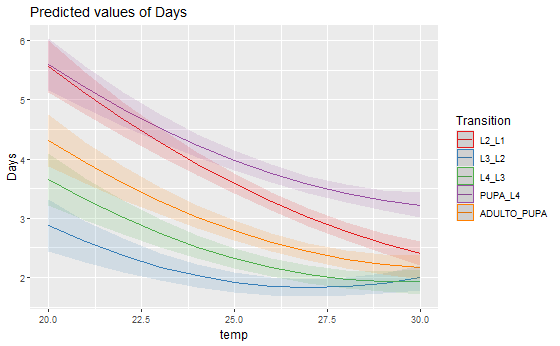

```r
plot_model(bestfull_glm, type = "pred", terms = c("temp[20:30]","Transition"),show.data = F)
```

```
$uniformity

    Asymptotic one-sample Kolmogorov-Smirnov test

data:  simulationOutput$scaledResiduals
D = 0.1, p-value = 3e-10
alternative hypothesis: two-sided


$dispersion

    DHARMa nonparametric dispersion test via sd of residuals fitted vs. simulated

data:  simulationOutput
dispersion = 1, p-value = 0.7
alternative hypothesis: two.sided


$outliers

    DHARMa outlier test based on exact binomial test with approximate expectations

data:  simulationOutput
outliers at both margin(s) = 21, observations = 980, p-value = 6e-05
alternative hypothesis: true probability of success is not equal to 0.00797
95 percent confidence interval:
 0.0133 0.0326
sample estimates:
frequency of outliers (expected: 0.00796812749003984 )
                                                0.0214
```

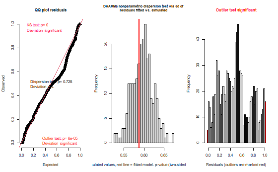

```r
#### Full model did not pass model assumptions
#Uniformity: not passed
#Dispersion: passed
#Outliers: not passed


simulateResiduals(bestfull_glm, plot =F)%>%testResiduals()
```

## Model immersion to adult

Assess how temperature and sex driven the time to adulthood from first time immersion

```r
#   MODEL - Full development
modeloADULTO_IMERSAO <- glm(ADULTO_IMERSION ~ SEXO+temp+I(temp^2), data = dados_log)
```

### Model selection and validation

```r
#Multi model selection
dredge_out<-dredge(modeloADULTO_IMERSAO)
```

```
Fixed term is "(Intercept)"
```

```r
dredge_out
```

```
Global model call: glm(formula = ADULTO_IMERSION ~ SEXO + temp + I(temp^2), data = dados_log)
---
Model selection table
  (Intrc) SEXO    temp    temp^2 df logLik AICc delta weight
8    6.69    + -0.2573  0.003888  5  159.5 -309   0.0  0.759
7    6.67      -0.2561  0.003855  4  157.3 -306   2.3  0.241
4    3.95    + -0.0497            4  151.3 -294  14.3  0.001
3    3.95      -0.0503            3  149.4 -293  16.0  0.000
6    3.28    +         -0.000917  4  147.2 -286  22.5  0.000
5    3.28              -0.000927  3  145.4 -285  24.1  0.000
2    2.63    +                    3   61.8 -117 191.3  0.000
1    2.60                         2   59.1 -114 194.7  0.000
Models ranked by AICc(x)
```

```r
best_alldev<-get.models(dredge_out, subset = 1)
best_alldev[[1]]%>%parameters::parameters(exponentiate=FALSE)
```

```
Parameter   | Coefficient |       SE |         95% CI | t(192) |      p
-----------------------------------------------------------------------
(Intercept) |        6.69 |     0.67 | [ 5.37,  8.01] |   9.93 | < .001
SEXO [M]    |       -0.03 |     0.02 | [-0.06,  0.00] |  -2.09 | 0.037
temp        |       -0.26 |     0.05 | [-0.36, -0.16] |  -5.07 | < .001
temp^2      |    3.89e-03 | 9.50e-04 | [ 0.00,  0.01] |   4.09 | < .001
```

```
Uncertainty intervals (profile-likelihood) and p-values (two-tailed) computed using a
  Wald t-distribution approximation.
```

```r
best_alldev[[1]]%>%anova()
```

```
Analysis of Deviance Table

Model: gaussian, link: identity

Response: ADULTO_IMERSION

Terms added sequentially (first to last)

          Df Deviance Resid. Df Resid. Dev     F   Pr(>F)
NULL                        195       6.28
SEXO       1     0.17       194       6.11  14.4   0.0002 ***
temp       1     3.66       193       2.45 311.9  < 2e-16 ***
I(temp^2)  1     0.20       192       2.25  16.8 0.000062 ***
---
Signif. codes:  0 ‘***’ 0.001 ‘**’ 0.01 ‘*’ 0.05 ‘.’ 0.1 ‘ ’ 1
```

```r
# Effect of the sex
(best_alldev[[1]]%>%parameters::parameters(exponentiate =TRUE))[2,]
```

```
Parameter | Coefficient |   SE |       95% CI | t(192) |     p
--------------------------------------------------------------
SEXO [M]  |        0.97 | 0.02 | [0.94, 1.00] |  -2.09 | 0.037
```

```
Uncertainty intervals (profile-likelihood) and p-values (two-tailed) computed using a
  Wald t-distribution approximation.
```

```
Object of Class DHARMa with simulated residuals based on 250 simulations with refit = FALSE . See ?DHARMa::simulateResiduals for help.

Scaled residual values: 0.62 0.48 0.456 0.304 0.848 0.428 0.172 0.028 0.672 0.172 0.312 0.072 0.524 0.24 0.976 0.38 0.036 0.988 0.256 0.764 ...
```

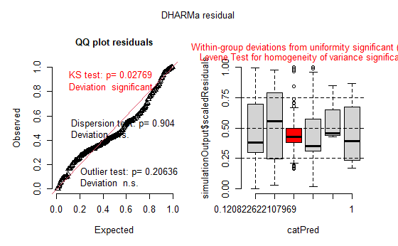

```r
simulateResiduals(best_alldev[[1]],plot=T)
```

Ainda que o modelo não tenha se adequado a todos os pressupostos, essa diferença parece ser mínima e o modelo parece ter apresentado um bom ajuste quando olhamos os resíduos dos valores ajustados

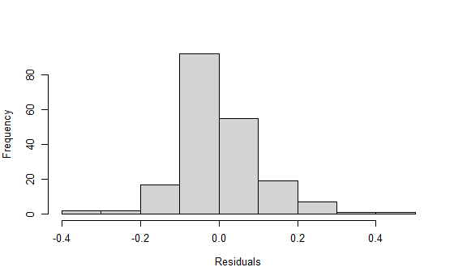

```r
hist(best_alldev[[1]]$residuals,xlab="Residuals",main=NULL)
```

```r
best_alldev_glm<-best_alldev[[1]]
```

### Plot

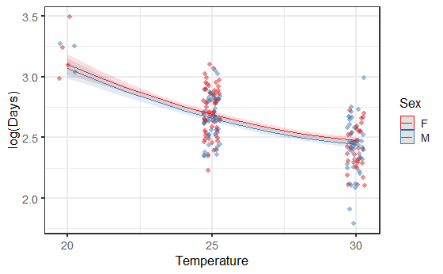

```r
plot_model(best_alldev_glm, show.data = T , jitter = .3,
    type = "pred", terms = c("temp[20:30]","SEXO"),transform)+
labs(x="Temperature",
    y="log(Days)",
    color="Sex")+
#xlab("Temperature")+
#ylab("log(Days)")+
labs(title=NULL)+
theme_bw(base_size=16)+
  theme_bw(base_size = 16)+
#  scale_y_continuous(
#    breaks = seq(log(1),log(40),by=log(log(5))),  # Intervalos de 5 em 5 de 1 a 40
#    labels = function(x) scales::label_number()(exp(x)))+
  scale_x_continuous(
    breaks = seq(20,30,by=5))
```

### Valores preditos

```r
ggpredict(best_alldev_glm,,terms = c("temp[20,25,30]"))%>%
  data.frame()%>%
  mutate(across(c(predicted, conf.low, conf.high), exp))
```

| x | predicted | std.error | conf.low | conf.high | group |
| --- | --- | --- | --- | --- | --- |
| 20 | 22.2 | 0.0415 | 20.5 | 24.1 | 1 |
| 25 | 14.7 | 0.0128 | 14.4 | 15.1 | 1 |
| 30 | 11.9 | 0.0151 | 11.5 | 12.2 | 1 |

```r
# Considering sex
best_alldev_pred<-ggpredict(best_alldev_glm,,terms = c("temp[20:30,by=.5]","SEXO"))%>%
data.frame()%>%
  mutate(across(c(predicted, conf.low, conf.high), exp)) %>%
  mutate(SE = (conf.high - conf.low) / (2 * 1.96))


best_alldev_pred
```

| x | predicted | std.error | conf.low | conf.high | group | SE |
| --- | --- | --- | --- | --- | --- | --- |
| 20.0 | 22.2 | 0.0415 | 20.5 | 24.1 | F | 0.930 |
| 20.0 | 21.5 | 0.0419 | 19.8 | 23.4 | M | 0.909 |
| 20.5 | 21.2 | 0.0357 | 19.7 | 22.7 | F | 0.761 |
| 20.5 | 20.5 | 0.0362 | 19.1 | 22.0 | M | 0.746 |
| 21.0 | 20.2 | 0.0305 | 19.0 | 21.4 | F | 0.619 |
| 21.0 | 19.5 | 0.0310 | 18.4 | 20.8 | M | 0.610 |
| 21.5 | 19.3 | 0.0259 | 18.3 | 20.3 | F | 0.502 |
| 21.5 | 18.6 | 0.0265 | 17.7 | 19.6 | M | 0.497 |
| 22.0 | 18.4 | 0.0219 | 17.7 | 19.2 | F | 0.406 |
| 22.0 | 17.8 | 0.0225 | 17.1 | 18.7 | M | 0.405 |

[output cut: 32 more lines]

```r
ggpredict(best_alldev_glm,,terms = c("temp[20:30,by=.5]","SEXO"))%>%
data.frame()%>%
  mutate(across(c(predicted, conf.low, conf.high), exp)) %>%
  mutate(SE = (conf.high - conf.low) / (2 * 1.96))%>%
group_by(group)%>%
  slice_min(order_by = predicted, n = 3)%>%
relocate(group,x)
```

| group | x | predicted | std.error | conf.low | conf.high | SE |
| --- | --- | --- | --- | --- | --- | --- |
| F | 30.0 | 11.9 | 0.0151 | 11.5 | 12.2 | 0.180 |
| F | 29.5 | 12.0 | 0.0138 | 11.7 | 12.3 | 0.167 |
| F | 29.0 | 12.2 | 0.0132 | 11.9 | 12.5 | 0.162 |
| M | 30.0 | 11.5 | 0.0138 | 11.2 | 11.8 | 0.159 |
| M | 29.5 | 11.6 | 0.0127 | 11.3 | 11.9 | 0.148 |
| M | 29.0 | 11.8 | 0.0122 | 11.5 | 12.1 | 0.145 |

# Development by stage

## Piecewise model fitting

We created an acessory function to help validate all models with one hit

```r
#   PIECEWISE MODEL FITTING

Stand_residout<-function(X){
 simul<-DHARMa::simulateResiduals(X)
    temp<-DHARMa::testResiduals(simul)
 out<-data.frame(
        Var=c("Uniformity(KS(D))","Dispersion","Outliers"),
            Stat=c(as.numeric(temp$uniformity[[1]]),
                as.numeric(temp$dispersion[[2]]),
                paste(as.numeric(temp$outliers[[1]]),"of",as.numeric(temp$outliers[[2]]))),
        p.value=c(temp$uniformity[[2]],
                temp$dispersion[[5]],
                paste(temp$outliers[[3]])))
return(out)}
```

Model fitting

```r
modL2_L1 <- glm(L2_L1 ~ temp+I(temp^2)+SEXO, data = dados_std)
modL3_L2 <- glm(L3_L2 ~ temp+I(temp^2)+SEXO, data = dados_std)
modL4_L3 <- glm(L4_L3 ~ temp+I(temp^2)+SEXO, data = dados_std)
modPUPA_L4 <- glm(PUPA_L4 ~ temp+I(temp^2)+SEXO, data = dados_std)
modADULTO_PUPA <- glm(ADULTO_PUPA ~ temp+I(temp^2)+SEXO, data = dados_std)

# Include all models in a list
mod_trans<-list(
  modL2_L1,
  modL3_L2,
  modL4_L3,
  modPUPA_L4,
  modADULTO_PUPA)
```

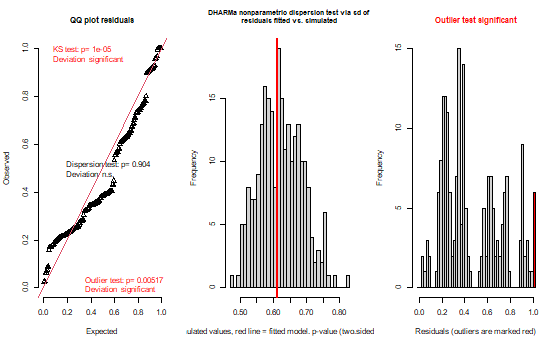

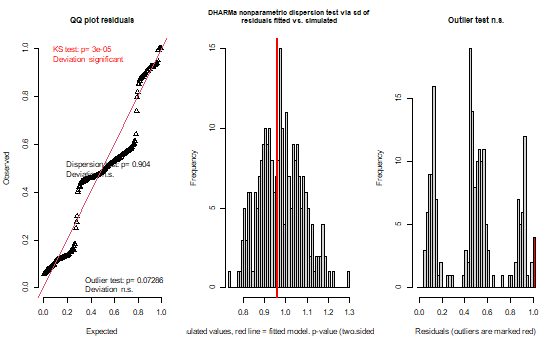

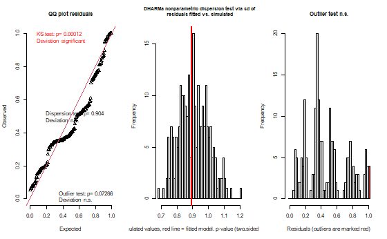

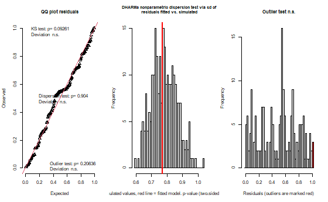

| Var | Stat | p.value |
| --- | --- | --- |
| Uniformity(KS(D)) | 0.177632653061224 | 8.4972352048345e-06 |
| Dispersion | 0.985344719512113 | 0.904 |
| Outliers | 6 of 196 | 0.00517150203739011 |

| Var | Stat | p.value |
| --- | --- | --- |
| Uniformity(KS(D)) | 0.168612244897959 | 0.0000289063935209284 |
| Dispersion | 0.985344719512113 | 0.904 |
| Outliers | 4 of 196 | 0.0728632030552171 |

| Var | Stat | p.value |
| --- | --- | --- |
| Uniformity(KS(D)) | 0.157591836734694 | 0.000118304810343453 |
| Dispersion | 0.985344719512113 | 0.904 |
| Outliers | 4 of 196 | 0.0728632030552171 |

| Var | Stat | p.value |
| --- | --- | --- |
| Uniformity(KS(D)) | 0.0885306122448979 | 0.0926136705492374 |
| Dispersion | 0.985344719512112 | 0.904 |
| Outliers | 3 of 196 | 0.206355353260413 |

| Var | Stat | p.value |
| --- | --- | --- |
| Uniformity(KS(D)) | 0.164040816326531 | 0.0000524666162015106 |
| Dispersion | 0.985344719512113 | 0.904 |
| Outliers | 5 of 196 | 0.0211282934375409 |

```
NA
```

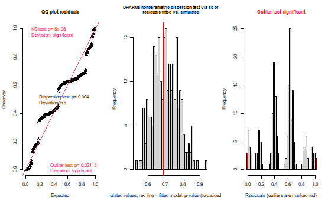

```r
# Check its parameters
lapply(mod_trans,Stand_residout) # Check residuals
```

```r
lapply(mod_trans,performance::r2) #Check R² for each model
```

```
[[1]]
  R2: 0.387

[[2]]
  R2: 0.029

[[3]]
  R2: 0.098

[[4]]
  R2: 0.226

[[5]]
  R2: 0.306
```

```r
lapply(mod_trans,parameters::parameters) # Extract parameters for each model
```

```
[[1]]
Parameter   | Coefficient |       SE |         95% CI | t(192) |     p
----------------------------------------------------------------------
(Intercept) |       -2.22 |     4.91 | [-11.84, 7.40] |  -0.45 | 0.651
temp        |        0.40 |     0.37 | [ -0.33, 1.12] |   1.08 | 0.280
temp^2      |       -0.01 | 6.91e-03 | [ -0.03, 0.00] |  -1.67 | 0.094
SEXO [M]    |       -0.11 |     0.11 | [ -0.34, 0.11] |  -1.01 | 0.311

[[2]]
Parameter   | Coefficient |       SE |         95% CI | t(192) |     p
----------------------------------------------------------------------
(Intercept) |        8.67 |     6.18 | [-3.44, 20.77] |   1.40 | 0.161
temp        |       -0.63 |     0.47 | [-1.54,  0.28] |  -1.35 | 0.176
temp^2      |        0.01 | 8.71e-03 | [-0.01,  0.03] |   1.32 | 0.187
SEXO [M]    |       -0.26 |     0.14 | [-0.54,  0.02] |  -1.85 | 0.065

[[3]]
Parameter   | Coefficient |       SE |         95% CI | t(192) |     p
----------------------------------------------------------------------
(Intercept) |       11.78 |     5.95 | [ 0.11, 23.44] |   1.98 | 0.048
temp        |       -0.78 |     0.45 | [-1.66,  0.10] |  -1.75 | 0.081
temp^2      |        0.01 | 8.39e-03 | [ 0.00,  0.03] |   1.51 | 0.132
SEXO [M]    |        0.05 |     0.14 | [-0.22,  0.32] |   0.39 | 0.699

[[4]]
Parameter   | Coefficient |       SE |         95% CI | t(192) |      p
-----------------------------------------------------------------------
(Intercept) |       30.38 |     5.51 | [19.57, 41.18] |   5.51 | < .001
temp        |       -2.17 |     0.42 | [-2.98, -1.35] |  -5.21 | < .001
temp^2      |        0.04 | 7.77e-03 | [ 0.02,  0.05] |   4.91 | < .001
SEXO [M]    |       -0.09 |     0.13 | [-0.34,  0.16] |  -0.68 | 0.500

[[5]]
Parameter   | Coefficient |       SE |         95% CI |   t(192) |      p
-------------------------------------------------------------------------
(Intercept) |       27.57 |     5.22 | [17.33, 37.80] |     5.28 | < .001
temp        |       -1.91 |     0.39 | [-2.68, -1.14] |    -4.84 | < .001
temp^2      |        0.03 | 7.36e-03 | [ 0.02,  0.05] |     4.41 | < .001
SEXO [M]    |    3.50e-04 |     0.12 | [-0.24,  0.24] | 2.90e-03 | 0.998
```

Two models example

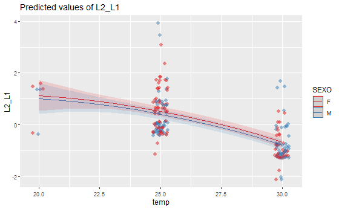

```r
plot_model(modL2_L1 , show.data = T , jitter = .3,
    type = "pred", terms = c("temp[20:30]","SEXO"),transform)
```

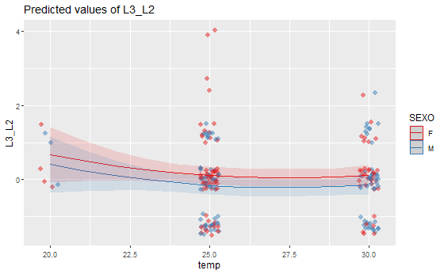

```r
plot_model(modL3_L2 , show.data = T , jitter = .3,
    type = "pred", terms = c("temp[20:30]","SEXO"))
```

## Estimate the effect of variables on stages

```r
stats<-c("Intercept","Temp","Temp_quad","SEXO")

effect_temp<-lapply(
            lapply(
              mod_trans,
                    parameters::parameters),
                        data.frame,stats=stats)

names(effect_temp)<-c("L1_L2","L2_L3","L3_L4","L4_Pupa","Pupa_Adulto")

effect_temp<-effect_temp%>%bind_rows(.,.id="Stages")%>%as_tibble()%>%
select( Stages,stats,Coefficient,SE,CI,CI_low,CI_high,p)%>%
filter(stats!="Intercept")%>%
mutate(p.value=ifelse(p>=0.05,"Non-sig","sig"))

effect_temp
```

| Stages | stats | Coefficient | SE | CI | CI_low | CI_high | p | p.value |
| --- | --- | --- | --- | --- | --- | --- | --- | --- |
| L1_L2 | Temp | 0.39904 | 0.36975 | 0.95 | -0.32566 | 1.12374 | 2.80e-01 | Non-sig |
| L1_L2 | Temp_quad | -0.01158 | 0.00691 | 0.95 | -0.02513 | 0.00198 | 9.41e-02 | Non-sig |
| L1_L2 | SEXO | -0.11475 | 0.11332 | 0.95 | -0.33686 | 0.10735 | 3.11e-01 | Non-sig |
| L2_L3 | Temp | -0.62967 | 0.46550 | 0.95 | -1.54204 | 0.28269 | 1.76e-01 | Non-sig |
| L2_L3 | Temp_quad | 0.01150 | 0.00871 | 0.95 | -0.00557 | 0.02856 | 1.87e-01 | Non-sig |
| L2_L3 | SEXO | -0.26326 | 0.14267 | 0.95 | -0.54288 | 0.01637 | 6.50e-02 | Non-sig |
| L3_L4 | Temp | -0.78275 | 0.44855 | 0.95 | -1.66188 | 0.09639 | 8.10e-02 | Non-sig |
| L3_L4 | Temp_quad | 0.01265 | 0.00839 | 0.95 | -0.00379 | 0.02909 | 1.32e-01 | Non-sig |
| L3_L4 | SEXO | 0.05315 | 0.13747 | 0.95 | -0.21629 | 0.32258 | 6.99e-01 | Non-sig |
| L4_Pupa | Temp | -2.16519 | 0.41555 | 0.95 | -2.97965 | -1.35072 | 1.88e-07 | sig |

[output cut: 5 more lines]

```r
NA
```

### Effect size by stage - plot

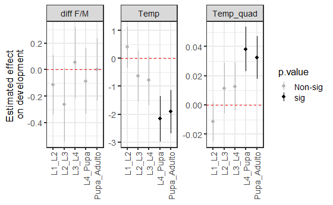

```r
effect_temp%>%
filter(stats!="Intercept")%>%
mutate(stats=ifelse(stats=="SEXO","diff F/M",stats))%>%
#filter(Stages!="Adulto_imersion")%>%
mutate(Stages=factor(Stages,levels=unique(effect_temp$Stages)))%>%
ggplot(.,aes(x=Stages,y=Coefficient,group=stats))+
#geom_line()+
geom_pointrange(aes(ymin = CI_low, ymax = CI_high,color=p.value))+
facet_wrap(.~stats,scale="free_y")+
theme_bw(base_size=16)+
geom_hline(yintercept=0, linetype="dashed", color = "red",linesize=.5)+
scale_color_manual(values=c("grey70","black"))+
ylab("Estimated effect \non development")+xlab(NULL)+
#ylab(paste0("Estimated effect of temperature \n on development ",bquote(beta[max](mu~mol ~CO[2]~ m^-2~s^-1))))+
#ylab(expression(atop("Estimated effect of temperature", "on development ( -1* "~beta[Temp]~")"))) +
#theme(axis.text.x = element_text(angle = 75, vjust = 1, hjust=1))
theme(axis.text.x = element_text(angle = 90, vjust = .5, hjust=1))+
facet_wrap(.~stats,scales="free_y")
```